# BIO 539 Annotating Cryptasterina

Jacob Green

5/8/2020

## Why annotate two sea star genomes: Hystera and Pentagona

Echinoderms are unique in the tree of life when it comes to diversity of lifecycles and modes of reproduction. Across the phylum we find everything from planktotrophy to lecithotrophy and all the nuances in between. Within *Echinodermata*, *Asteroidea*, or Sea stars, exhibit a stunning array of processes when it comes to modes of development, parental investment, larval dispersal, and morphological diversity. On the Austrailian coastline of south east Queensland near Statue Bay two species of Sea star (*Cryptasterina hystera* and *Cryptasterina pentagona*) exhibit a striking and recent divergence in reproductive mode. These two species are morphologically identical, only distinguishable through molecular data and a reproductive period where you will find larvae brooding inside *C. hystera*. The ancestral line of this genus are broadcast spawners and have planktotrophic larvae, but very recently in evolutionary history *C. hystera* began retaining its larvae creating a reproductive rift between itself and *C. pentagona*. In 2019, Dr. Jon Puritz traveled to Statue Bay, Queensland to start a pilot study for defining the molecular dynamics of this shift in reproductive mode. We collected tissue samples for the two species and sequenced nanopore, DNA, and RNA reads. We generated a genome assembly for each species and the scope of this project is to annotate those two assemblies. These annotations will inform preliminary research into the molecular basis of shifting reproductive modes in closely related cogener species of sea stars.

## Process of Annotation

Names are important, as names give meaning and in many cases derive the function of a thing. This is no different for genomes. Annotations are the descriptions of structural and functional regions of genomic sequences. Annotating open reading frames (ORF), coding and noncoding regions, high repetitive regions, transposable elements, and other functional elements of genomes are integral to translating genetic sequences into data points that can inform research. There are two stages to the process of annotation 1) alignment/mapping 2) gene prediction/naming. Alignment involves matching your seqeuence reads to the genome and mapping involves assigning quality to how the reads matched, where they match to on the genome, and the length of the matched fragment. For gene prediction and naming we take those aligned mapped fragments and align them to sequences in databases that have been curated. These curated databases hold a plethora of information that can then be collated and used in a variety of ways. There are a multitude of programs that can be leveraged to do both. In the scope of this project we will be using BUSCO, dammit, Quast, Diamond, Hisat2, CD-hit-est, Maker, and Braker2 for these processes.

## Cryptasterina Workflow

How am I structuring this annotation process?

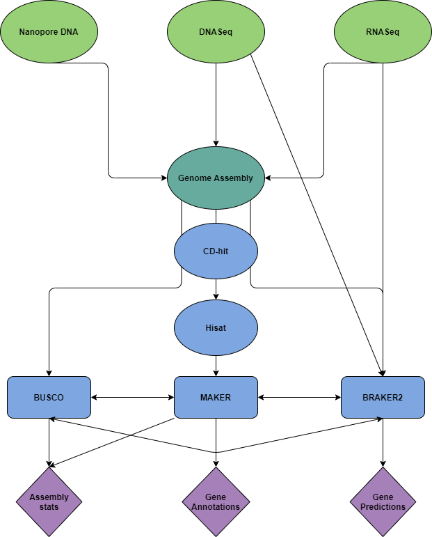

Programming workflow for annotating genomes

Looks a little something like this. Many of the annotation programs are depedent on the output of other programs.

## Making working directories, locating assemblies, and linking files

Jon provided me with the location of the sequencing reads and assemblies.

First I’ll make a directory to house my work

```bash
#make the working directory
mkdir cryptasterina
```

I will be working with linked versions of the assemblies.

```bash
#link command using the -s as symbolic and then the direct path of the directories
ln -s /RAID_STORAGE2/Shared_Data/Cryptasterina/Hystera/
ln -s /RAID_STORAGE2/Shared_Data/Cryptasterina/Pentagona/
```

Now I have all the files located in my home.

What is in these directories?

```bash
#listing out what is in the Pentagona directory. This includes updated information from project work
ls -alh /home/jgreen/cryptasterina/Pentagona
```

```
## total 24K
## drwxr-xr-x+ 3 jgreen jgreen 4.0K May  8 18:11 .
## drwxr-xr-x+ 7 jgreen jgreen  124 May  8 18:11 ..
## -rw-r--r--+ 1 jgreen jgreen 1.4K May  8 18:11 maker_bopts.ctl
## -rw-r--r--+ 1 jgreen jgreen 1.5K May  8 18:11 maker_exe.ctl
## -rw-r--r--+ 1 jgreen jgreen 4.4K May  8 18:11 maker_opts.ctl
## lrwxrwxrwx  1 jgreen jgreen   82 May  8 18:11 nanopore.filtered.trimmed.fq.gz -> /RAID_STORAGE2/Shared_Data/Cryptasterina/Pentagona/nanopore.filtered.trimmed.fq.gz
## lrwxrwxrwx  1 jgreen jgreen   78 May  8 18:11 pentagona_assemblyV49.fasta -> /RAID_STORAGE2/Shared_Data/Cryptasterina/Pentagona/pentagona_assemblyV49.fasta
## drwxr-xr-x+ 5 jgreen jgreen 4.0K May  8 18:11 pentagona_assemblyV49.fasta.dammit
## lrwxrwxrwx  1 jgreen jgreen   72 May  8 18:11 Pentagona.RNA.F.fq.gz -> /RAID_STORAGE2/Shared_Data/Cryptasterina/Pentagona/Pentagona.RNA.F.fq.gz
## lrwxrwxrwx  1 jgreen jgreen   72 May  8 18:11 Pentagona.RNA.R.fq.gz -> /RAID_STORAGE2/Shared_Data/Cryptasterina/Pentagona/Pentagona.RNA.R.fq.gz
## lrwxrwxrwx  1 jgreen jgreen   66 May  8 18:11 trimmed.F.fq.gz -> /RAID_STORAGE2/Shared_Data/Cryptasterina/Pentagona/trimmed.F.fq.gz
## lrwxrwxrwx  1 jgreen jgreen   66 May  8 18:11 trimmed.R.fq.gz -> /RAID_STORAGE2/Shared_Data/Cryptasterina/Pentagona/trimmed.R.fq.gz
```

```bash
#listing out what is in the Hystera directory. This includes updated information from project work
ls /home/jgreen/cryptasterina/Hystera
```

```
## hystera_assemblyV9_nanopore_only.fasta
## hystera_assemblyV9_nanopore_only.fasta.dammit
## Hystera.RNA.F.fq.gz
## Hystera.RNA.R.fq.gz
## maker_bopts.ctl
## maker_exe.ctl
## maker_opts.ctl
## Nanopore.filtered.trimmed.total.fq.gz
## temp
```

In these assemblies we find there there are a few difference between the assemblies that we have. Specifically, the Hystera files do not have paired end reads. This is an artifact that our lab sent in the wrong samples and duplicated the Pentagona reads. This disparity caused some issues early in the project. We had to redo many of the initial analysis for hystera.

## Using Bioconda: the good, the bad, the ugly

Bioconda is a channel for the conda package manager specializing in bioinformatics software. The conda package manager makes installing software a vastly more streamlined process. Im going to be using Bioconda as a way to install tools such as BUSCO, dammit, Quast, Diamond, Hisat2, CD-hit-est, Maker, and Braker2. This allows me to manage the various dependencies for each of these programs.

Typically I would want to create one environment for all of these programs, but they have different dependencies that Bioconda is unable to rectify. I’ll be making individual environments for each.

We have to make sure that we have the correct channels installed for Bioconda to work.

```bash
#move to the home directory
cd ~
#run the minconda sh script and configure each channel. If the channels are configured already the program will give you a check on the run.
./Miniconda3-latest-Linux-x86_64.sh
conda config --add channels defaults
conda config --add channels conda-forge
conda config --add channels bioconda
```

## BUSCO

BUSCO is already installed in my environments but i’ll add the code here to install and update

```bash
#create the new (-n) environment (busco) and install package (busco)
conda create -n busco busco
#update package if new versionw as upload to the bioconda repository
conda update busco
```

Make a directory for our busco results

```bash
#move to the cryptasterina working directory
cd ~/cryptasterina/
#make directory busco to house results
mkdir busco
```

Run the BUSCO python script for the eukaryota and metazoa database

```bash
#python command givne the direct path to the program (.py), the assembly (-i), the database lineage (-l), the mode (-m), and the number of threads (--cpu)
python /home/jgreen/miniconda3/pkgs/busco-1.2-py27_1/bin/BUSCO_v1.2.py -i /home/jgreen/cryptasterina/Hystera/hystera_assemblyV9_nanopore_only.fasta -o hystera_busco_euk -l /home/jgreen/databases/eukaryota_odb9/ -m genome --cpu 4

python /home/jgreen/miniconda3/pkgs/busco-1.2-py27_1/bin/BUSCO_v1.2.py -i /home/jgreen/cryptasterina/Hystera/hystera_assemblyV9_nanopore_only.fasta -o hystera_busco_meta -l /home/jgreen/databases/metazoa_odb9/ -m genome --cpu 4
```

Here are the results from the BUSCO runs.

```bash
#view results from the busco run through the short summary file
cat ~/cryptasterina/busco/run_hystera_busco_meta/short_summary_hystera_busco_meta

cat ~/cryptasterina/busco/run_hystera_busco_euk/short_summary_hystera_busco
```

```
## #Summarized BUSCO benchmarking for file: hystera_assemblyV9_nanopore_only.fasta
## #BUSCO was run in mode: genome
##
## Summarized benchmarks in BUSCO notation:
##  C:91%[D:1.9%],F:2.3%,M:6.3%,n:978
##
##  893 Complete BUSCOs
##  874 Complete and single-copy BUSCOs
##  19  Complete and duplicated BUSCOs
##  23  Fragmented BUSCOs
##  62  Missing BUSCOs
##  978 Total BUSCO groups searched
## #Summarized BUSCO benchmarking for file: hystera_assemblyV9_nanopore_only.fasta
## #BUSCO was run in mode: genome
##
## Summarized benchmarks in BUSCO notation:
##  C:93%[D:1.6%],F:2.3%,M:4.6%,n:303
##
##  282 Complete BUSCOs
##  277 Complete and single-copy BUSCOs
##  5   Complete and duplicated BUSCOs
##  7   Fragmented BUSCOs
##  14  Missing BUSCOs
##  303 Total BUSCO groups searched
```

```bash
#view results from the busco run through the short summary file
cat ~/cryptasterina/busco/run_pentagona_busco_meta/short_summary_pentagona_busco_meta

cat ~/cryptasterina/busco/run_pentagona_busco_euk/short_summary_pentagona_busco
```

```
## #Summarized BUSCO benchmarking for file: pentagona_assemblyV49.fasta
## #BUSCO was run in mode: genome
##
## Summarized benchmarks in BUSCO notation:
##  C:91%[D:3.2%],F:2.1%,M:6.0%,n:978
##
##  898 Complete BUSCOs
##  866 Complete and single-copy BUSCOs
##  32  Complete and duplicated BUSCOs
##  21  Fragmented BUSCOs
##  59  Missing BUSCOs
##  978 Total BUSCO groups searched
## #Summarized BUSCO benchmarking for file: pentagona_assemblyV49.fasta
## #BUSCO was run in mode: genome
##
## Summarized benchmarks in BUSCO notation:
##  C:93%[D:2.3%],F:1.9%,M:4.6%,n:303
##
##  283 Complete BUSCOs
##  276 Complete and single-copy BUSCOs
##  7   Complete and duplicated BUSCOs
##  6   Fragmented BUSCOs
##  14  Missing BUSCOs
##  303 Total BUSCO groups searched
```

Although this is a nice text format we would like an image, which can be generated by the BUSCO program

Link all the short_summary files into one directory. Move into that directory and then run the following code.

```bash
#run generate plot .py script in the directory containg all short summary files
generate_plot.py -wd .
```

Which produces this lovely graph.

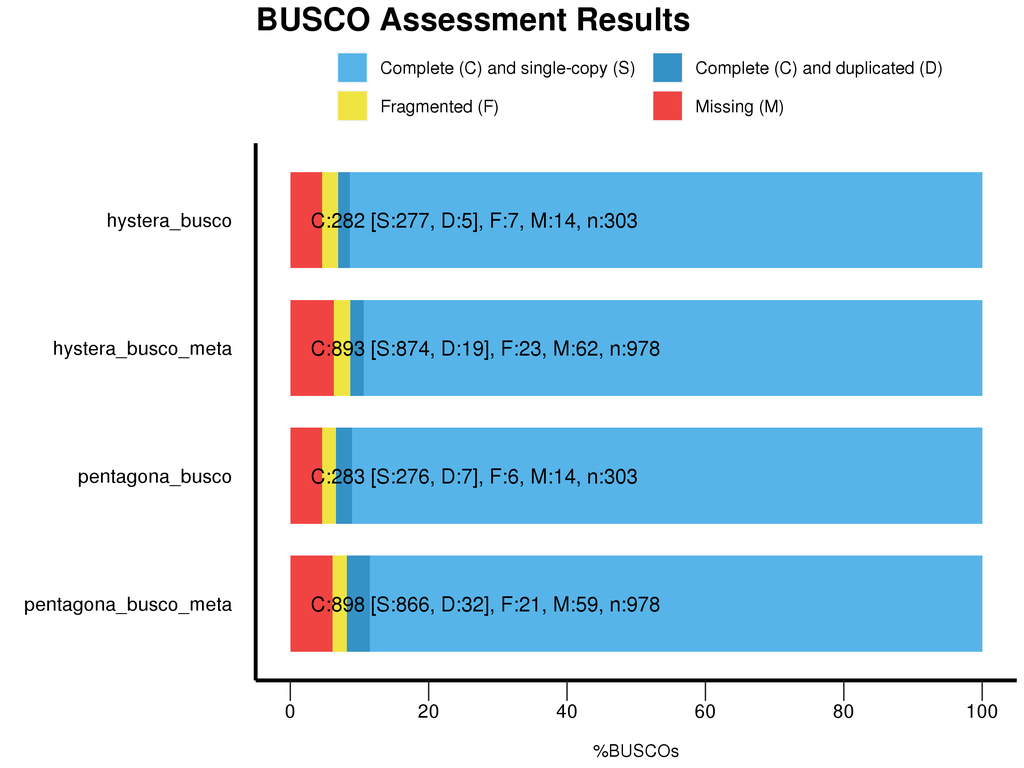

Hystera and Pentagona Metazoa and Eukaryota BUSCO Results